# LuthraSauravPS6

Saurav Luthra

2025-04-27

# SAURAV LUTHRA, MTH643 PROBLEM SET 6

## =========== OVERVIEW ===========

## =========== SETUP ===========

## =========== QUESTION 1 ===========

#### [**ARCH(1) Process - Xt**]

We have that,

$\{\varepsilon_t\}_{t=-\infty}^{\infty}$ is defined by:

$$\epsilon_t \sim \mathcal{N}(0, 1), i.i.d.$$

$\{X_t\}$ is defined by:

$$X_t = \varepsilon_t \cdot \sqrt{1 + \left(0.5 X_{t-1}\right)^2}$$

$\{X_t\}$ is a weakly stationary process and satisfies the form of an ARCH(1) (Auto Regressive Conditional Heteroskedasticity) model with parameter $\alpha = 0.5$.

ARCH models, including the one simulated here, are generally weakly stationary, meaning that their mean and variance remain constant over time and their autocovariance depends only on the lag between observations, not on the specific time points. This differs from strict stationarity, which requires the full joint distribution to be invariant to shifts in time. To assess the presence of autocorrelation in the simulated series, the Ljung-Box test was applied to both realizations at lags 5, 10, and 15. In all cases, the resulting p-values were well above the 0.05 significance threshold, indicating no evidence of linear autocorrelation in the series. This outcome aligns with the theoretical expectations for ARCH processes, where despite a lack of correlation in the series values, the squared values often have significant autocorrelation.

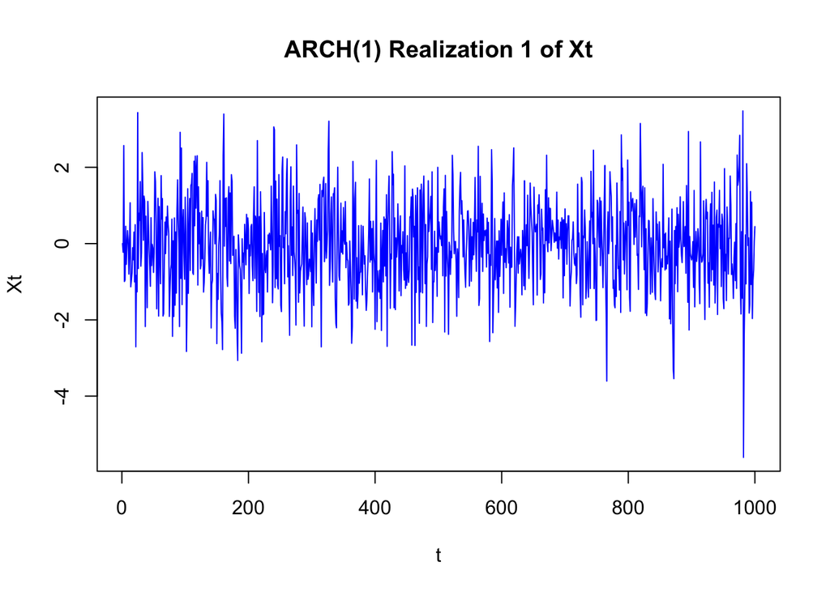

```r
# ==============================================================================
# SIMULATION OF 2 Xt REALIZATIONS FOR 1000 STEPS

# setup
set.seed(416)
n <- 1000
alpha <- 0.5

# vectors for the 2 realizations
X1 <- numeric(n)
X2 <- numeric(n)

# initial values
X1[1] <- 0
X2[1] <- 0

# simulate the process from t=2 to t=1000
for (t in 2:n) {

  # epsilon values
  eps1 <- rnorm(1)
  eps2 <- rnorm(1)

  # X values
  X1[t] <- eps1 * sqrt(1 + (alpha * X1[t - 1])^2)
  X2[t] <- eps2 * sqrt(1 + (alpha * X2[t - 1])^2)
}

# plot 2 realizations
ts.plot(X1, col = "blue", main = "ARCH(1) Realization 1 of Xt", ylab = "Xt", xlab = "t")
```

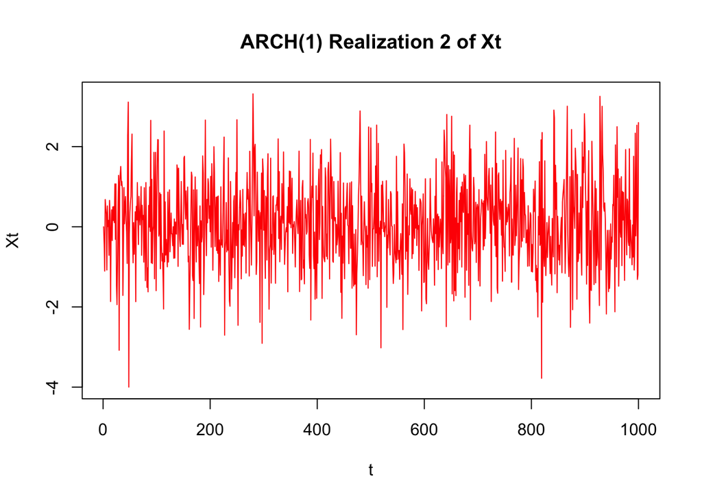

```r
ts.plot(X2, col = "red",  main = "ARCH(1) Realization 2 of Xt", ylab = "Xt", xlab = "t")
```

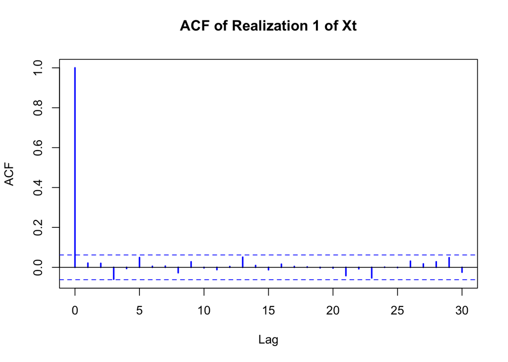

```r
# plot autocorrelation functions of 2 realizations
acf(X1, main = "ACF of Realization 1 of Xt", col = "blue", lwd = 2)
```

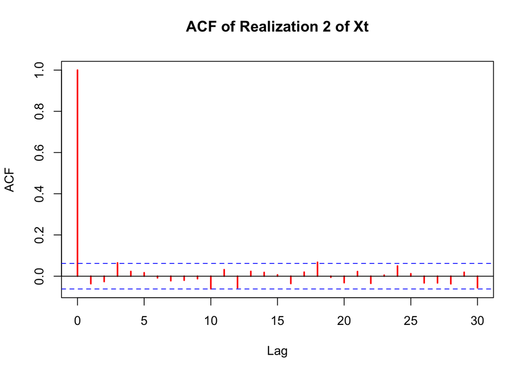

```r
acf(X2, main = "ACF of Realization 2 of Xt", col = "red", lwd = 2)
```

```r
# ==============================================================================
# LJUNG-BOX TESTS ON 2 REALIZATIONS OF Xt

Box.test(X1, lag = 5, type = "Ljung-Box")
```

```
##
##  Box-Ljung test
##
## data:  X1
## X-squared = 6.9034, df = 5, p-value = 0.2279
```

```r
Box.test(X2, lag = 5, type = "Ljung-Box")
```

```
##
##  Box-Ljung test
##
## data:  X2
## X-squared = 7.0353, df = 5, p-value = 0.218
```

```r
Box.test(X1, lag = 10, type = "Ljung-Box")
```

```
##
##  Box-Ljung test
##
## data:  X1
## X-squared = 8.5171, df = 10, p-value = 0.5785
```

```r
Box.test(X2, lag = 10, type = "Ljung-Box")
```

```
##
##  Box-Ljung test
##
## data:  X2
## X-squared = 11.955, df = 10, p-value = 0.2881
```

```r
Box.test(X1, lag = 15, type = "Ljung-Box")
```

```
##
##  Box-Ljung test
##
## data:  X1
## X-squared = 11.547, df = 15, p-value = 0.713
```

```r
Box.test(X2, lag = 15, type = "Ljung-Box")
```

```
##
##  Box-Ljung test
##
## data:  X2
## X-squared = 17.12, df = 15, p-value = 0.3117
```

## =========== QUESTION 2 ===========

#### [Log-Returns and Squared Log-Returns of HP and PDS]

The squaring of log returns has the interesting effect of acting as a proxy for measuring variance at each time point, since variance is defined as the expected value of the squared deviation from the mean. While the raw log returns fluctuate around zero with no persistent pattern, squaring them transforms all deviations into positive values and emphasizes the magnitude of changes regardless of direction. This transformation reveals autocorrelation in the volatility that is not visible in the returns themselves. The positive sample autocorrelations in the squared log returns indicates that large/small return magnitudes are more likely to be followed by similar large/small return magnitudes, even if the direction of the return changes (markets have some of the biggest positive returns during crashes). This is an important feature of financial time series that ARCH and GARCH models are better able to capture.

There is still significant autocorrelation in both stocks’ log returns and squared log returns according to the Ljung-Box test, however, the p-values on the squared log returns are several orders of magnitude less than those of the log return series. This indicates that the degree of autocorrelation in the absolute magnitude of returns (direction-agnostic volatility) is much, much more statistically significant than that of simple log returns.

```r
# ==============================================================================
# SETUP 4 LOG-RETURN & LOG-RETURN-SQUARED SERIES FOR HP AND PDS

getSymbols("HP", src = "yahoo", from = as.Date("2020-02-01", to = as.Date("2025-02-01")))
```

```
## [1] "HP"
```

```r
HP_log_returns <- as.vector(diff(log((HP$HP.Adjusted)))[-1])
HP_log_returns_2 <- HP_log_returns^2

getSymbols("PDS", src = "yahoo", from = as.Date("2020-02-01", to = as.Date("2025-02-01")))
```

```
## [1] "PDS"
```

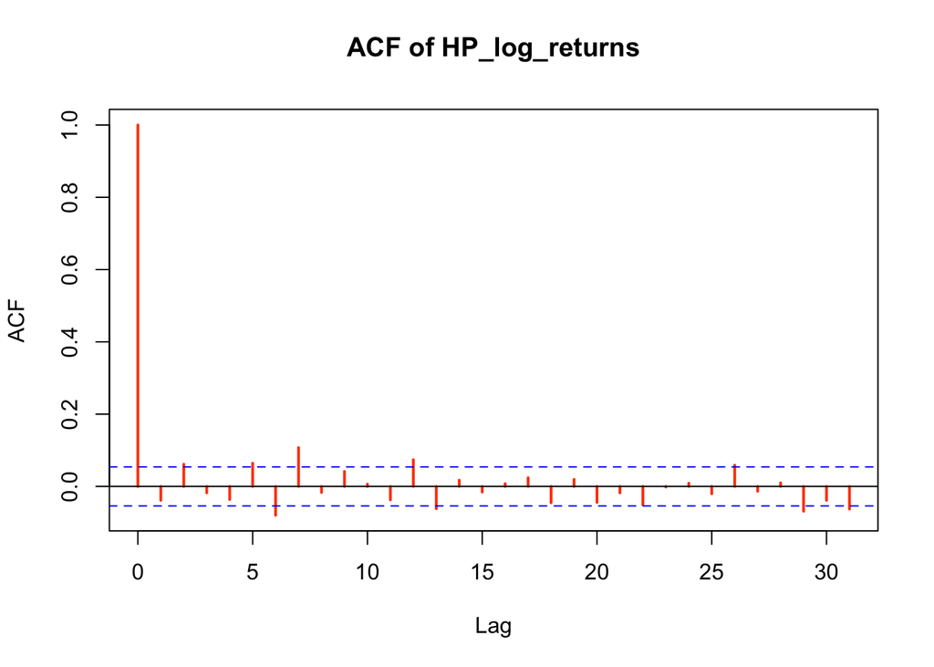

```r
PDS_log_returns <- as.vector(diff(log((PDS$PDS.Adjusted)))[-1])
PDS_log_returns_2 <- PDS_log_returns^2

# ==============================================================================
# SAMPLE ACF OF 4 SERIES

acf(HP_log_returns,   main = "ACF of HP_log_returns",   col = "orangered", lwd = 2)
```

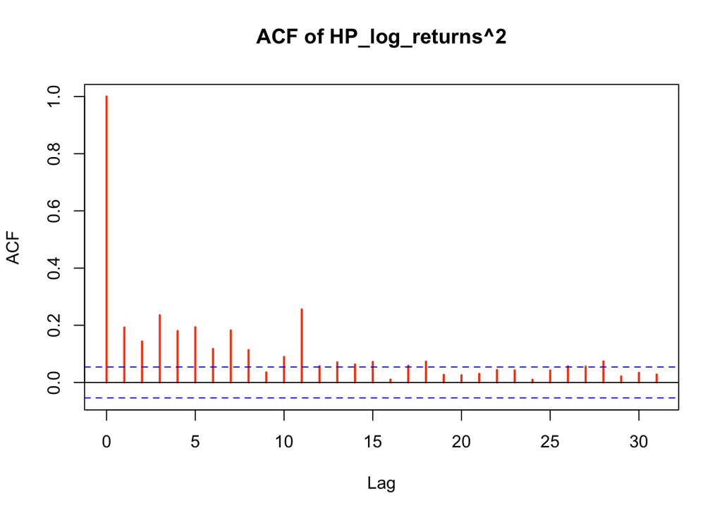

```r
acf(HP_log_returns_2, main = "ACF of HP_log_returns^2", col = "orangered", lwd = 2)
```

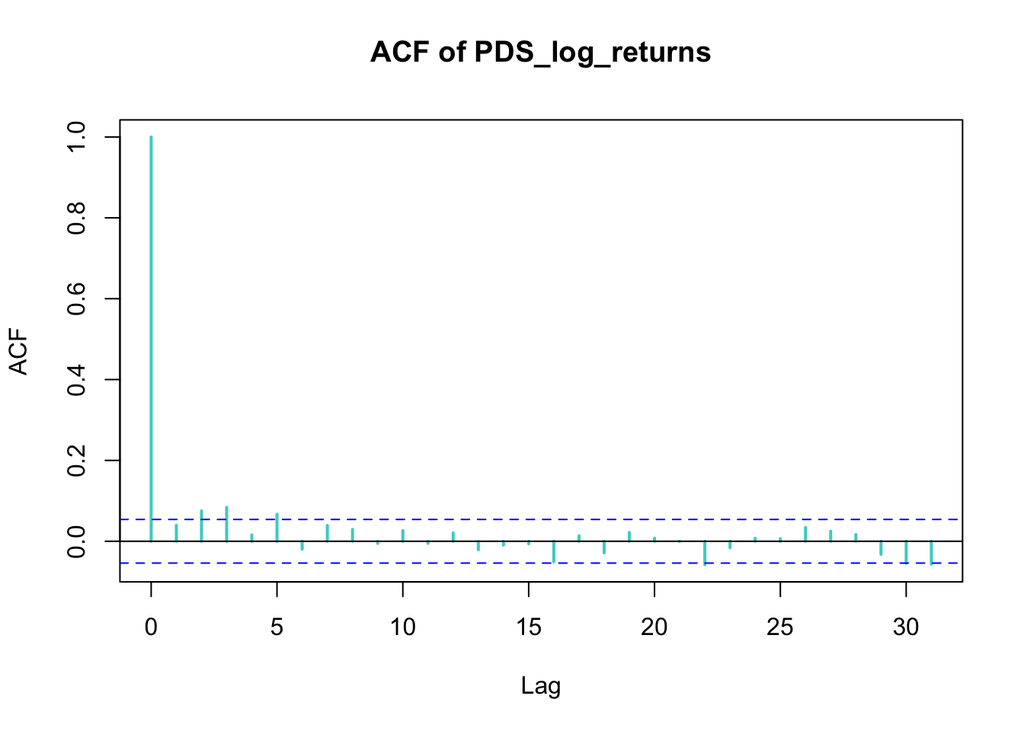

```r
acf(PDS_log_returns, main = "ACF of PDS_log_returns", col = "mediumturquoise", lwd = 2)
```

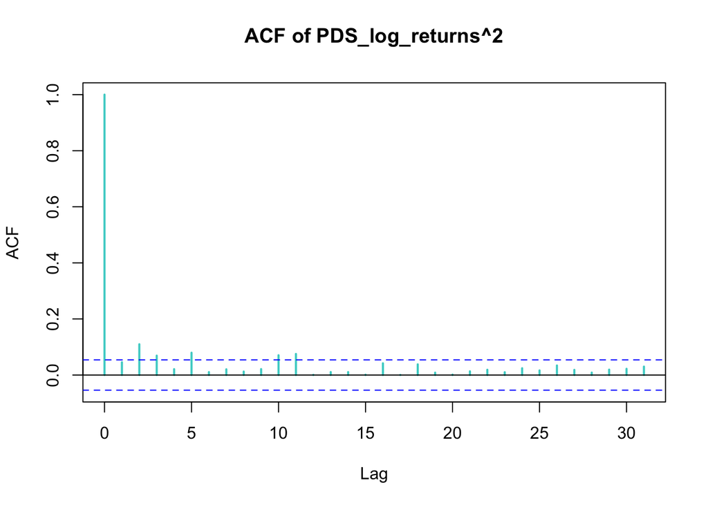

```r
acf(PDS_log_returns_2, main = "ACF of PDS_log_returns^2", col = "mediumturquoise", lwd = 2)
```

```r
# ==============================================================================
# LJUNG-BOX TEST FOR LOG-RETURN AND SQUARED LOG-RETURN OF HP AND PDS

m <- 5

Box.test(HP_log_returns,   lag = m, type = "Ljung-Box")
```

```
##
##  Box-Ljung test
##
## data:  HP_log_returns
## X-squared = 14.589, df = 5, p-value = 0.01227
```

```r
Box.test(HP_log_returns_2, lag = m, type = "Ljung-Box")
```

```
##
##  Box-Ljung test
##
## data:  HP_log_returns_2
## X-squared = 241.52, df = 5, p-value < 2.2e-16
```

```r
Box.test(PDS_log_returns,   lag = m, type = "Ljung-Box")
```

```
##
##  Box-Ljung test
##
## data:  PDS_log_returns
## X-squared = 25.106, df = 5, p-value = 0.0001329
```

```r
Box.test(PDS_log_returns_2, lag = m, type = "Ljung-Box")
```

```
##
##  Box-Ljung test
##
## data:  PDS_log_returns_2
## X-squared = 34.013, df = 5, p-value = 2.367e-06
```

## =========== QUESTION 3 ===========

#### [ARCH(1) Process - **Yt**]

Question 3(A)

Let $Y_t$ be an ARCH(1) process defined by:

$$Y_t = \epsilon_t \cdot \sigma_t, \quad
\text{where } \sigma_t^2 = \alpha_0 + \alpha_1 Y_{t-1}^2$$

Here:

$$\epsilon_t \sim \mathcal{N}(0, 1),
i.i.d.$$

$$\alpha_0 > 0$$

$$0 \leq \alpha_1 < 1$$

The process $Y_t$ is weakly stationary, so:

$$\mathbb{E}[Y_t] = 0$$
$$\text{Var}(Y_t) = \mathbb{E}[Y_t^2]$$
which is constant over time.

**We want to show that:**

$$\text{Var}(Y_t) = \frac{\alpha_0}{1 -
\alpha_1}$$

To find $\text{Var}(Y_t)$, we start by squaring both sides of the definition of $Y_t$:

$$Y_t^2 = \epsilon_t^2 \cdot
\sigma_t^2$$

Next, substitute the expression for $\sigma_t^2$:

$$Y_t^2 = \epsilon_t^2 \cdot (\alpha_0 +
\alpha_1 Y_{t-1}^2)$$

Now take the expectation of both sides. Because $\epsilon_t$ is independent of $Y_{t-1}$, and $\epsilon_t^2$ has mean 1 (since $\epsilon_t \sim \mathcal{N}(0,1)$), we get:

$$\mathbb{E}[Y_t^2] =
\mathbb{E}[\epsilon_t^2] \cdot \mathbb{E}[\alpha_0 + \alpha_1 Y_{t-1}^2]
= 1 \cdot (\alpha_0 + \alpha_1 \mathbb{E}[Y_{t-1}^2])$$

Since the process is weakly stationary, $\mathbb{E}[Y_t^2] = \mathbb{E}[Y_{t-1}^2] = \gamma$ for some constant $\gamma$. Therefore:

$$\gamma = \alpha_0 + \alpha_1
\gamma$$

Now plug in and solve for $\gamma$ algebraically:

$$\gamma - \alpha_1 \gamma = \alpha_0
\quad \Rightarrow \quad \gamma (1 - \alpha_1) = \alpha_0 \quad
\Rightarrow \quad \gamma = \frac{\alpha_0}{1 - \alpha_1}$$

Thus, we have:

$$\text{Var}(Y_t) = \mathbb{E}[Y_t^2] =
\frac{\alpha_0}{1 - \alpha_1}$$

Question 3(B)

In this simulation, the first realization of Yt^2 had much lower parameter values, and thus we expect it to have much less volatility persistence (and therefore less autocorrelation) than the 2nd realization. For an AR(1) process we would expect to see strong positive values for the first lags, and then an exponential decay in the ACF. The sample ACFs do in fact display that, and we can also see that although both realizations are autocorrelated with their own previous values, the exponential decay on the first realization is much quicker, due to its lower parameter values. This intuitively shows that raising the parameter values, and by extension the volatility persistence, can noticeably change the autocorrelation behavior in the Yt^2 process. Additionally, using the Ljung-Box tests (with lags set to 10), we can see that both series have significant autocorrelation, but, the p-value for the 2nd realization is several orders of magnitude less, indicating a much stronger evidence of autocorrelation.

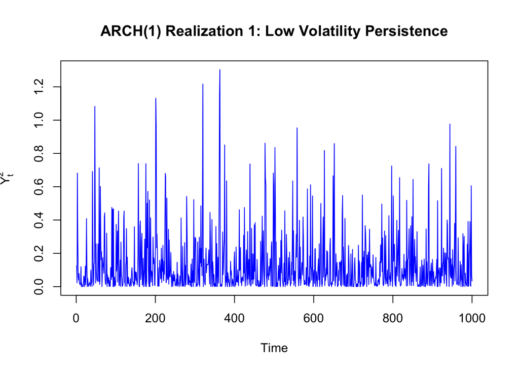

```r
# ==============================================================================
# 2 REALIZATIONS OF (Yt)^2 WITH VERY DIFFERENT PARAMETERS AND 1000 TIME STEPS

# seed for reproducibility
set.seed(416)

# 1000 steps
n <- 1000

# vectors to store Y^2 for 2 realizations
Y_sq_1 <- numeric(n)
Y_sq_2 <- numeric(n)

# sharply different parameter values - different volatility persistence
alpha0_1 <- 0.1
alpha1_1 <- 0.2

alpha0_2 <- 0.8
alpha1_2 <- 0.9

# initial values based on formula for theoretical unconditional variance
Y_sq_1[1] <- alpha0_1 / (1 - alpha1_1)
Y_sq_2[1] <- alpha0_2 / (1 - alpha1_2)

# generate standard normal innovations
epsilon <- rnorm(n)

# simulate both processes
for (t in 2:n) {
  sigma_sq_1 <- alpha0_1 + alpha1_1 * Y_sq_1[t - 1]
  sigma_sq_2 <- alpha0_2 + alpha1_2 * Y_sq_2[t - 1]

  Y_sq_1[t] <- (epsilon[t])^2 * sigma_sq_1
  Y_sq_2[t] <- (epsilon[t])^2 * sigma_sq_2
}

# plot the realizations
plot(Y_sq_1, type = "l", col = "blue", main = "ARCH(1) Realization 1: Low Volatility Persistence", ylab = expression(Y[t]^2), xlab = "Time")
```

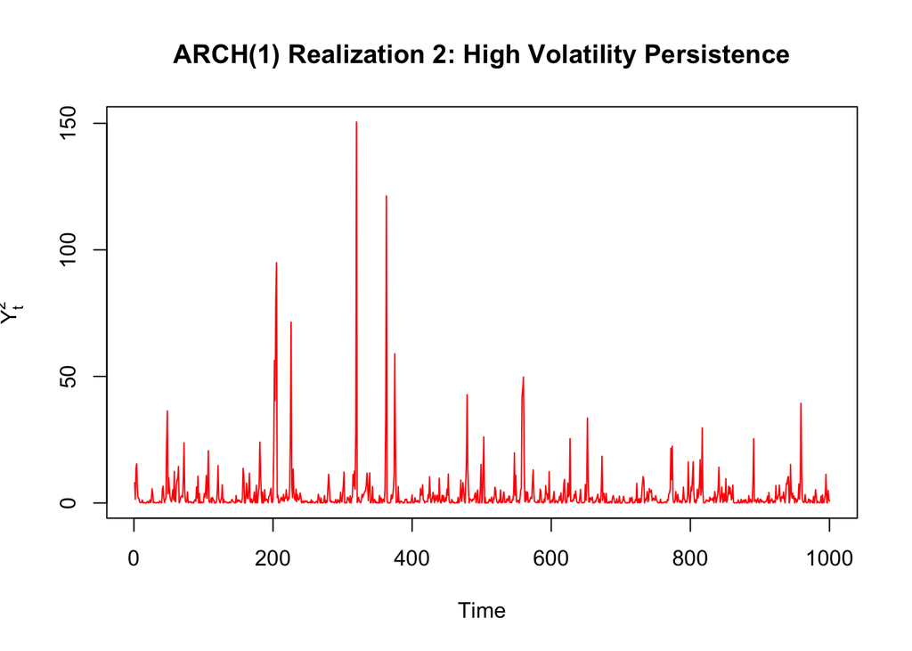

```r
plot(Y_sq_2, type = "l", col = "red", main = "ARCH(1) Realization 2: High Volatility Persistence", ylab = expression(Y[t]^2), xlab = "Time")
```

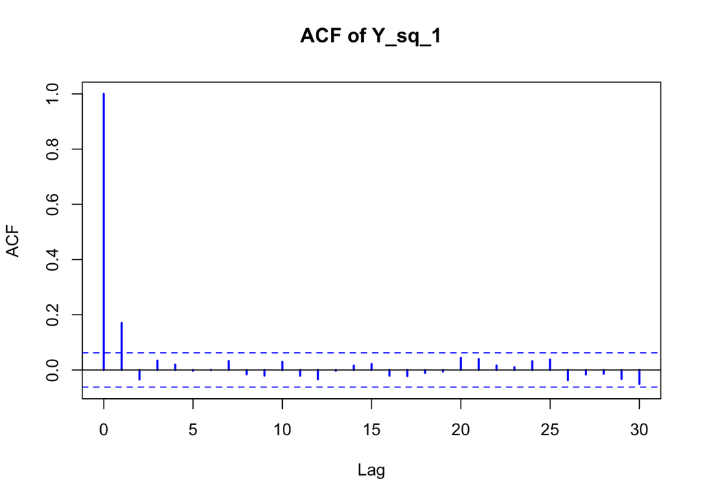

```r
# plot the sample acfs and perform the ljung-box tests
m <- 10

acf(Y_sq_1, main = "ACF of Y_sq_1", col = "blue", lwd = 2)
```

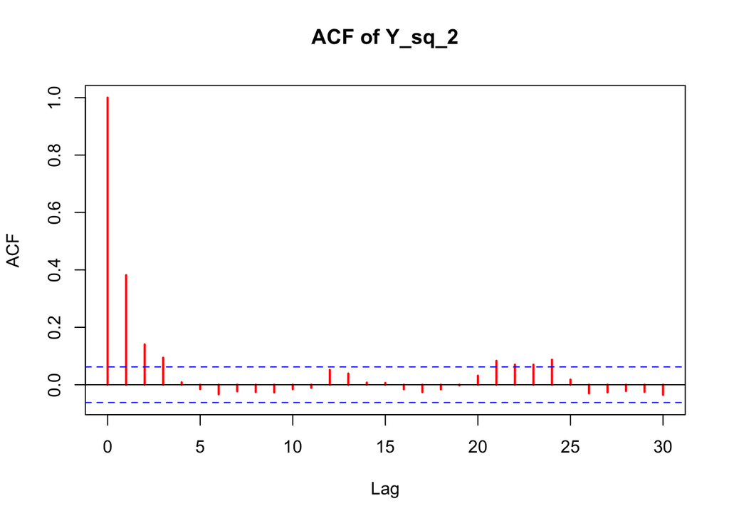

```r
acf(Y_sq_2, main = "ACF of Y_sq_2", col = "red", lwd = 2)
```

```r
Box.test(Y_sq_1, lag = m, type = "Ljung-Box")
```

```
##
##  Box-Ljung test
##
## data:  Y_sq_1
## X-squared = 34.471, df = 10, p-value = 0.0001536
```

```r
Box.test(Y_sq_2, lag = m, type = "Ljung-Box")
```

```
##
##  Box-Ljung test
##
## data:  Y_sq_2
## X-squared = 178.41, df = 10, p-value < 2.2e-16
```